# A3: Incarceration

Lufei Chen

8/4/2023

### Introduction

The United States has the highest incarceration rate in the world, a problem that has received widespread attention. In this analysis, I have chosen to focus on the “total prison population”. This variable provides a comprehensive understanding of the magnitude and scope of the incarceration issue in the U.S. In this report, through the use of line charts, bar charts, and maps, I will investigate population differences by race, gender, and region, in order to understand disparities within the prison system and reveal patterns of inequality and injustice in the judicial system.

### Summary Information

I was curious to know what is the highest rate of incarceration in the total population, and in which city it occurs. Through my research, I found that in 2006, Mcpherson County, NE, had a strikingly high incarceration rate of 33.78%. This result underscores the disparities in incarceration rates across different regions within the United States.

Additionally, I wondered whether there were connections and differences between states and the prison population. I discovered that the five states with the highest incarceration rates in the United States are California, Texas, Florida, New York, and Georgia. I used the term ‘top_five_prison_pop’ in the code to denote this. This signifies that California has the state with the highest number of incarcerated individuals.

In an effort to identify which city in California has had the highest incarcerated population in recent years, I used the “county” variable for this investigation. In 2016, Los Angeles had the largest incarcerated population, reaching 42,940 people.

The “gender-ratio” indicates that the ratio of male to female prison population in recent years is about 12.38%. Finally, I examined the first year of the dataset, which is 1970. During this period, the ratio of men to women in the prison population was 41.04%. This shows that social norms, law enforcement practices, and criminal behaviors have shifted over the past few decades.

### The Dataset

Who collected the data?  
The data was collected by the Vera Institute of Justice.

How was the data collected or generated? The dataset was collected using two data sources from the Bureau of Justice Statistics (BJS): the Census of Jails (COJ) and the Annual Survey of Jails (ASJ). This data was collected through surveys, administrative records, and other forms of data collection.

Why was the data collected? The purpose of collecting the data is to understand the trends of prisons and their populations in the United States. By analyzing the dataset, we can study the influence and differences in incarceration situations based on factors such as race, gender, and region. Through this analysis, we aim to encourage government and judicial reforms to achieve a more equitable justice system. Moreover, we hope that through this dataset we can gain a more realistic understanding of the situation of incarceration in the United States.

How many observations (rows) are in your data?  
I used the split files called the dataset about prison population per county/state. There are 153811 observations.

How many features (columns) are in the data?  
I used the split files called the dataset about prison population per county/state. There are 9 features.

What, if any, ethical questions or questions of power do you need to consider when working with this data?  
While working with this data, we need to consider some privacy issues. Data related to the prison population could contain sensitive information. Although the data does not include detailed personal information and identities, it cannot prevent it from being inferred from the data. So we should ensure that personal privacy will not be disclosed. Moreover, we need to consider the validity and accuracy of the data, and whether there is bias.

What are possible limitations or problems with this data? (at least 200 words) One of the primary concerns we need to consider is whether the data on the US prison population is complete. Notably, when drawing the map, I found that data for some states were missing, which could easily lead to bias in the results or an inaccurate description of the overall trend. Additionally, the data set lacks data during certain years such as 2018, which could lead to misjudgment of the trend of the prison population, thereby affecting the validity of the analysis and leading to potentially misleading conclusions.

We also need to consider the accuracy of the data. If the sources of the data set are not reliable, misunderstandings of data requirements or inaccurate data entry can lead to errors in their reported data. For example, reporting errors in the number of inmates of certain races and genders may lead to underestimation and distort the results. Moreover, when the prison population data is not all collected by census surveys, there could be sampling biases. In other words, when the surveyed inmate sample does not represent more or all of the population, there would be deviations and errors in the data, affecting its accuracy. Finally, if there is a gap in the data between years, it may also affect the trend judgment of the prison population.

### Trends Over Time Chart

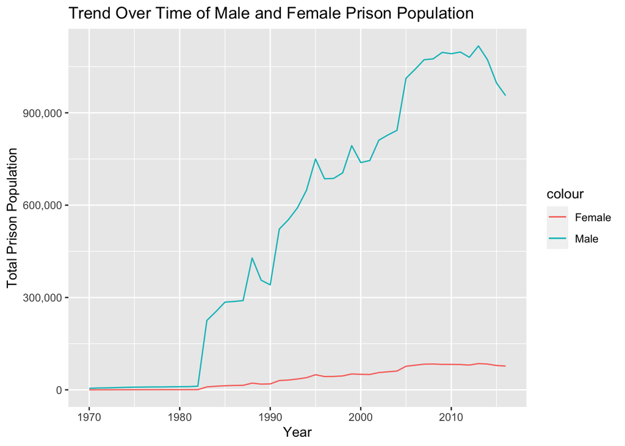

### Variable Comparison Chart

The reason for including this chart is to clearly demonstrate the racial disparities within the prison systems across different states in the United States. The patterns that have emerged from this chart underscore the pronounced racial imbalance in incarceration rates, particularly between Black and White populations.

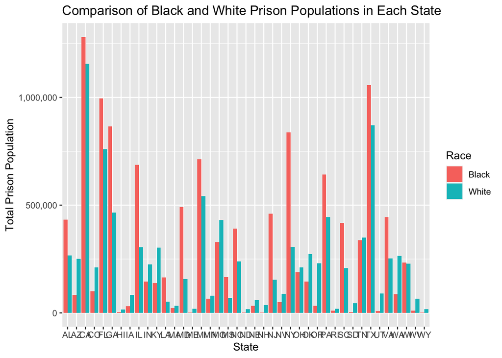

### Map

In the third chart, I utilized varying colors to illustrate the fluctuations in prison populations across different states, as represented on a topographic map from 1970 to 2018. Lighter colors signify a lower count of individuals in a particular state’s prison population, while darker shades suggest a larger number of people in a state’s prison population. Gray represents the absence values.

The chart shows that California and Texas are highlighted in deep red, indicating that these states have the largest prison populations. I guess this is due to a high population density or a higher incidence of crime. On the other hand, states with smaller population densities, such as Wyoming and Maine, are represented in lighter colors, suggesting fewer prison populations. The map highlights the disparities in prison populations across different states in a visually impact manner. The patterns emerging from this chart clearly illustrate that prison populations vary significantly by state, potentially influenced by factors such as population density and local law enforcement practices.

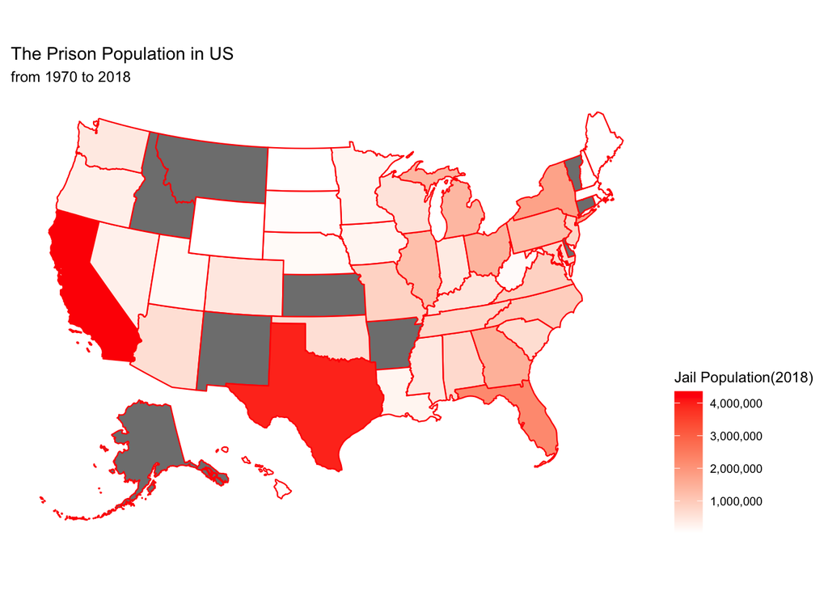